# ☕ Coffee Vicscha: Análisis de Consumo y Estrategias de Rentabilidad

Victoria Díaz y Schantal Gutiérrez

22 de octubre de 2025

El éxito operativo y comercial de una cadena de cafeterías como ‘VICSHA’ se encuentra en la capacidad de comprender y anticipar ciertos aspectos o patrones de consumo de nuestros clientes. Comprendiendo que cada una de las transacciones registradas en sus múltiples sedes es una valiosa pieza de información que, al ser analizada, permite tomar decisiones estratégicas de alto impacto para la franquicia. Este análisis se sumerge en los datos de ventas de vicsha para entender qué impulsa el consumo, cuándo ocurre y cómo optimizarlo.

## 1 Planteamiento del problema

El éxito operativo y comercial de una cadena de cafeterías como ‘VICSHA’ se encuentra en la capacidad de comprender y anticipar ciertos aspectos o patrones de consumo de nuestros clientes. Comprendiendo que cada una de las transacciones registradas en sus múltiples sedes es una valiosa pieza de información que, al ser analizada, permite tomar decisiones estratégicas de alto impacto para la franquicia. Este análisis se sumerge en los datos de ventas de vicsha para entender qué impulsa el consumo, cuándo ocurre y cómo optimizarlo.

Este informe esta enfocado en realizar un Análisis Exploratorio de Datos del conjunto de datos de ventas de ‘VICSHA’. Nuestro objetivo principal es convertir los datos brutos de transacciones en información práctica y útil para la toma de decisiones y asi poder optimizar la oferta de productos, gestionar el inventario y mejorar la rentabilidad en cada punto de venta.

Nos haremos preguntas sencillas para determinar puntos claves para el desarrollo y mejora de la compañía preguntadonos, ¿cómo puede una cafetería identificar sus productos estrella, sus horarios más rentables y sus oportunidades de mejora? para asi saber que patrones de consumo revelan los datos y cómo pueden traducirse en decisiones estratégicas?

## 2 🎯 Objetivos del estudio

### 2.1 ✅ Objetivo general

Analizar el comportamiento de consumo en la franquicia *VICSHA* a partir de datos reales de ventas, con el fin de identificar patrones de rentabilidad, segmentación temporal y oportunidades estratégicas para mejorar la eficiencia operativa y comercial.

### 2.2 📌 Objetivos específicos

- Identificar los productos con mayor impacto en los ingresos totales.
- Analizar la variación del consumo según categoría de producto.
- Detectar franjas horarias y días clave que concentran el flujo de ventas.
- Construir visualizaciones limpias y narrativas técnicas que faciliten la interpretación de los hallazgos.
- Proponer estrategias basadas en evidencia para optimizar la oferta, reforzar la operación y mejorar la experiencia del cliente.

## 3 📚 Marco Teórico

Este estudio esta basado en la estadística descriptiva, con el objetivo de identificar patrones transaccionales que permitan tomar decisiones estratégicas en la franquicia VICSHA.

Para ello empleamos :

• Medidas de tendencia central : media, mediana, moda para caracterizar el ticket promedio.

• Medidas de dispersión : desviación estándar, rango, cuartiles y desviación respecto a la mediana para evaluar la variabilidad en los ingresos.

• Segmentación temporal: agrupación por mes y por turno horario para detectar ciclos de consumo.

• Agrupamiento por categoría y ubicación: para comparar desempeño entre sucursales y tipos de producto.

## 4 🧪 Marco Metodológico

### 4.1 Enfoque y Tipo de Investigación

El estudio tiene un enfoque cuantitativo descriptivo-exploratorio, el cual orientamos a identificar patrones de consumo para asi buscar y generar conocimiento accionable a partir de datos reales.

### 4.2 Fuente de Datos

Los datos provienen del archivo “Coffee Shop Sales.xlsx” , que contiene registros de transacciones realizadas en distintas sucursales de VICSHA. Las variables incluyen: Identificadores como variables temporales, variables de consumo y Variables derivadas

### 4.3 Procesamiento de Datos

Para hacer mas comprensible el analisis de datos aplicamos las siguientes transformaciones para mejorar la legibilidad del analisis:

• Renombramiento de variables con nombres semánticos : usamos rename() para dar nombres claros a las variables (- transaction_id → id_transaccion, etc.).

Variables derivadas:

- total_ingresos: producto entre cantidad y precio unitario.
- mes_abreviado: extraído de la fecha (%b) y convertido a mayúsculas.
- hora: extraída de la hora de transacción.
- turno: clasificado con case_when() según la hora (mañana, tarde/noche, noche).
- Conversión de formatos: transformamos transaction_time a tipo datetime con ymd_hms().

Este procesamiento se hizo para poder segmentar los datos por mes, turno, sucursal y categoría de producto, facilitando el análisis.

### 4.4 Limpieza de Datos

Lo primero que se realizo fue verificar los valores nulos por variable usando colSums() y colMeans() para contar y calcular el porcentaje de nulos por variable y generamos un gráfico con ggplot2 para visualizar qué variables tienen nulos (rojo) y cuáles están completas (verde).

Luego verificamos los valores extremos revisando con summary() los rangos de precios y cantidades, y asi detectamos si había precios o cantidades menores o iguales a cero.

Y por ultimo hicimos la validación estructural donde confirmamos que las variables estén correctamente tipadas (chr, num, POSIXct) y documentamos los cambios en una tabla con kableExtra, indicando qué variables que se modificaron y por qué.

### 4.5 Análisis Estadístico

El análisis estadístico se llevó a cabo de manera integral, estructurando los cálculos por Sucursal (donde se analizaron el total de transacciones, ingresos y medidas de dispersión), por Categoría de producto (enfocándose en el conteo, ingresos y estadísticos descriptivos), por Mes (examinando el comportamiento mensual y el coeficiente de variación) y por Turno horario (mediante un análisis detallado por franja de consumo). Además, para una evaluación más granular, se aplicó este mismo esquema analítico de forma individual a cada tienda específica: Astoria, Lower Manhattan y Hell’s Kitchen.

## 5 📈 Resultados y Análisis

El análisis lo representaremos en cuatro niveles: por sucursal, por categoría de producto, por mes y por turno horario. Empleamos medidas estadísticas descriptivas y visualizaciones limpias para identificar patrones de consumo y oportunidades estratégicas.

### 5.1 🟫 Análisis por Sucursal

Este análisis de distribución de ingresos por sucursal la realizamos con el propósito de identificar los patrones de consumo específicos de cada ubicación y detectar oportunidades estratégicas de crecimiento para la cadena Vícsha. La necesidad de este estudio surgió de la premisa de que cada sucursal opera en un contexto geográfico y demográfico diferente, lo que probablemente genera comportamientos de compra distintivos entre sus clientes, y asi determinamos que estas diferencias nos permite desarrollar estrategias comercializadas que maximicen el potencial de cada localización, optimicen la asignación de recursos y mejoren la rentabilidad general del negocio.

Se opto por un enfoque metodológico que emplea gráficos de violín y boxplots de manera conjunta ya que esta elección de visualización proporciona una visión completa de la distribución de los datos.

Los gráficos de violín ilustran la densidad de las transacciones, lo que nos permite identificar los rangos de precio donde se concentra el mayor volumen de ventas. Por su parte, los boxplots superpuestos ofrecen métricas estadísticas esenciales: la mediana, los cuartiles y los valores atípicos y asi al combinar ambas herramientas, podemos ir más allá del simple valor típico de una transacción por sucursal. Logramos comprender tanto la variabilidad como la forma completa de la distribución de ingresos.

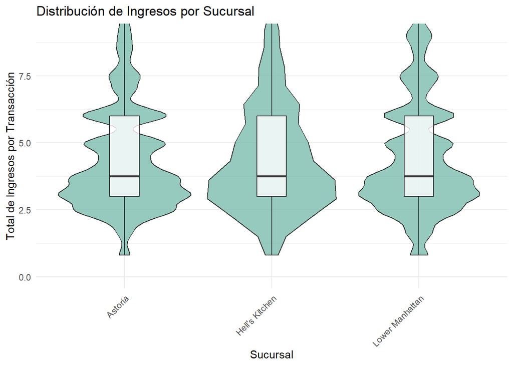

### 5.2 SUCURSAL ASTORIA

La distribución de ingresos nos conduce al análisis más significativo: el desempeño por sucursal. Entender el comportamiento global de VICHSA es valioso, pero el verdadero insight surge al examinar las variables en cada ubicación específica. Esta perspectiva permite a los directivos tomar decisiones más precisas y evaluar el rendimiento real de cada sucursal dentro de la marca.

| mes_abreviado | transacciones | ingreso_total | ingreso_minimo | ingreso_maximo | rango_ingresos | ingreso_promedio | ingreso_mediano | desviacion_ingresos | desviacion_mediana | cv_ingresos | q1_ingresos | q3_ingresos |
| --- | --- | --- | --- | --- | --- | --- | --- | --- | --- | --- | --- | --- |
| MES ENE | 5913 | 27313.66 | 0.8 | 45 | 44.2 | 4.62 | 3.75 | 3.07 | 3.19 | 66.44 | 3 | 6 |
| MES FEB | 5490 | 25105.34 | 0.8 | 45 | 44.2 | 4.57 | 3.75 | 2.75 | 2.87 | 60.12 | 3 | 6 |
| MES MAR | 7180 | 32835.43 | 0.8 | 45 | 44.2 | 4.57 | 3.75 | 2.88 | 2.99 | 62.88 | 3 | 6 |
| MES ABR | 8556 | 39477.61 | 0.8 | 45 | 44.2 | 4.61 | 3.75 | 2.88 | 3 | 62.37 | 3 | 6 |
| MES MAY | 11475 | 52428.76 | 0.8 | 45 | 44.2 | 4.57 | 3.75 | 2.83 | 2.95 | 61.93 | 3 | 6 |
| MES JUN | 11985 | 55083.11 | 0.8 | 45 | 44.2 | 4.6 | 3.75 | 2.88 | 3.01 | 62.76 | 3 | 6 |

**Indicadores clave del desempeño de la Sucursal Astoria por mes**

**📊 Volumen de Transacciones por Mes** - **Mes con mayor volumen**: Junio (11,985 transacciones) - **Mes con menor volumen**: Febrero (5,490 transacciones) - **Tendencia**: Crecimiento progresivo de Febrero a Junio

**💰 Ingresos Totales** - **Mes con mayores ingresos**: Junio ($55,083.11) - **Mes con menores ingresos**: Febrero ($25,105.34) - **Correlación**: Volumen de transacciones se relaciona directamente con ingresos totales

**📈 Análisis del Centro de la Distribución (Media vs. Mediana)** - **Mediana constante**: 3.75 en todos los meses - **Media fluctuante**: Entre 4.57 y 4.62 - **Relación media-mediana**: La media consistentemente mayor que la mediana en aproximadamente 0.82-0.87 puntos - **Interpretación**: La distribución está sesgada hacia la derecha, indicando presencia de valores altos que elevan el promedio por encima del valor típico (mediana)

**📋 Dispersión de Ingresos** - **Mes con mayor dispersión relativa**: Enero (CV: 66.44%) - **Mes con menor dispersión relativa**: Febrero (CV: 60.12%) - **Rango constante**: 44.2 en todos los meses (mínimo: 0.8, máximo: 45)

**🎯 Perspectiva para Directivos**

Esta información proporciona a los directivos:

**Métrica de Valor Típico** - La mediana constante de 3.75 representa el ingreso típico por transacción

**Identificación de Outliers** - La diferencia consistente entre media y mediana sugiere transacciones de mayor valor que distorsionan el promedio

**Estabilidad Operativa** - Los cuartiles constantes (Q1=3, Q3=6) indican comportamiento predecible en la distribución central. La estabilidad observada en los cuartiles (Q1=3 y Q3=6) a lo largo de todos los meses indica que el núcleo del negocio mantiene una estructura operativa predecible y consistente. Esto significa que, independientemente de las fluctuaciones en el volumen total de transacciones, la distribución fundamental de los ingresos por venta se preserva intacta.

| turno | transacciones | ingreso_total | ingreso_minimo | ingreso_maximo | rango_ingresos | ingreso_promedio | ingreso_mediano | desviacion_ingresos | desviacion_mediana | cv_ingresos | q1_ingresos | q3_ingresos |
| --- | --- | --- | --- | --- | --- | --- | --- | --- | --- | --- | --- | --- |
| HORARIO DE LA MAÑANA | 29828 | 136571.59 | 0.8 | 45 | 44.2 | 4.58 | 3.75 | 2.92 | 3.04 | 63.81 | 3 | 6 |
| HORARIO DE LA TARDE/NOCHE | 20771 | 95672.32 | 0.8 | 45 | 44.2 | 4.61 | 3.75 | 2.81 | 2.94 | 61.08 | 3 | 6 |

**Indicadores clave del desempeño de la Sucursal Astoria por turno**

**📊 Volumen de Transacciones por Turno** - **Turno con mayor volumen**: Horario de la Mañana (29.828 transacciones) - **Turno con menor volumen**: Horario de la Tarde/Noche (20.771 transacciones) - **Diferencia**: 9,057 transacciones a favor del turno matutino

**💰 Ingresos Totales por Turno** - **Turno con mayores ingresos**: Horario de la Mañana ($136.571,59) - **Turno con menores ingresos**: Horario de la Tarde/Noche ($95.672,32)

**📈 Análisis del Centro de la Distribución (Media vs. Mediana)** - **Mediana constante**: 3.75$ en ambos turnos - **Media similar**: Mañana (4.58USD) vs Tarde/Noche (4.61USD)

**📋 Dispersión de Ingresos por Turno** - **Turno con mayor dispersión relativa**: Horario de la Mañana (CV: 63.81%) - **Turno con menor dispersión relativa**: Horario de la Tarde/Noche (CV: 61.08%) - **Rango constante**: 44.2USD en ambos turnos (mínimo: 0.8, máximo: 45)

**🎯 Perspectiva para Directivos**

Esta información proporciona a los directivos:

**Eficiencia Operativa por Turno** - El turno de la mañana presenta una densidad operacional significativamente mayor, con 9,057 transacciones adicionales respecto al turno de la tarde/noche, concentrando aproximadamente 3 de cada 5 transacciones totales de la sucursal y estableciendo una clara preponderancia del horario matutino en el volumen de negocio.

**Consistencia en el Valor Típico** - La mediana idéntica (3.75) indica que el ingreso por transacción típico es igual en ambos turnos

**Estabilidad en la Distribución Central** - Los cuartiles constantes (Q1=3, Q3=6) confirman comportamiento predecible en ambos horarios

**Diferencias en Variabilidad** - El turno matutino presenta mayor dispersión relativa, posiblemente debido a mayor diversidad de clientes o patrones de compra

**Optimización de Recursos** - La consistencia en métricas clave permite asignación eficiente de personal e inventario según la demanda por turnos

| categoria_producto | transacciones | ingreso_total | ingreso_minimo | ingreso_maximo | rango_ingresos | ingreso_promedio | ingreso_mediano | desviacion_ingresos | desviacion_mediana | cv_ingresos | q1_ingresos | q3_ingresos |
| --- | --- | --- | --- | --- | --- | --- | --- | --- | --- | --- | --- | --- |
| Bakery | 7289 | 26599.75 | 3 | 9 | 6 | 3.65 | 3.5 | 0.73 | 0.75 | 20.09 | 3.25 | 3.75 |
| Branded | 279 | 5457 | 12 | 28 | 16 | 19.56 | 14 | 7.12 | 9.02 | 36.41 | 14 | 28 |
| Coffee | 20025 | 89744.3 | 2 | 8.5 | 6.5 | 4.48 | 4 | 1.86 | 1.92 | 41.56 | 3 | 6 |
| Coffee beans | 502 | 10219.2 | 10 | 45 | 35 | 20.36 | 19.75 | 8.43 | 8.45 | 41.42 | 15 | 21 |
| Drinking Chocolate | 4300 | 26335.25 | 3.5 | 9.5 | 6 | 6.12 | 4.75 | 2.23 | 2.62 | 36.35 | 3.75 | 9 |
| Flavours | 1490 | 1764.8 | 0.8 | 1.6 | 0.8 | 1.18 | 0.8 | 0.4 | 0.55 | 33.76 | 0.8 | 1.6 |
| Loose Tea | 344 | 3194 | 8.95 | 10.95 | 2 | 9.28 | 8.95 | 0.61 | 0.7 | 6.6 | 8.95 | 9.5 |
| Packaged Chocolate | 110 | 1089.71 | 6.4 | 13.33 | 6.93 | 9.91 | 7.6 | 2.99 | 3.77 | 30.22 | 7.6 | 13.33 |
| Tea | 16260 | 67839.9 | 2.5 | 8 | 5.5 | 4.17 | 4 | 1.53 | 1.54 | 36.79 | 2.55 | 5.1 |

**Indicadores clave del desempeño de la Sucursal Astoria por producto**

**📊 Participación en Volumen de Transacciones** - **Categoría líder**: Coffee (20,025 transacciones - 40% del total) - **Segunda categoría**: Tea (16,260 transacciones - 32% del total) - **Tercera categoría**: Bakery (7,289 transacciones - 14% del total) - **Categorías menores**: Representan colectivamente el 14% restante

**📈 Análisis de Valor por Transacción** - **Premium**: Coffee beans (20.36USD promedio) y Branded (19.56USD promedio) - **Medio**: Packaged Chocolate (9.91USD) y Loose Tea (9.28USD) - **Básico**: Flavours (1.18USD) y Bakery (3.65USD)

**Relación Media vs. Mediana por Categoría** - **Coffee beans**: Media (20.36USD) > Mediana (19.75USD) - ligero sesgo positivo - **Branded**: Media (19.56USD) > Mediana (14USD) - fuerte sesgo positivo - **Bakery**: Media (3.65USD) ≈ Mediana (3.5USD) - distribución casi simétrica - **Flavours**: Media (1.18USD) > Mediana ($0.8USD) - sesgo positivo marcado

**🎯 Perspectiva para Marketing y Directivos**

**Estrategia de Portafolio** - Coffee y Tea representan el 72% del volumen y 67% de los ingresos - productos core del negocio - Categorías premium (Coffee beans, Branded) muestran alto valor promedio pero bajo volumen

**Oportunidades de Mix Comercial**

- Bakery tiene alta rotación pero bajo valor promedio. Existe una oportunidad para estrategias de upselling, tales como: ofrecer combos que incluyan productos de bakery con bebidas premium (coffee beans o branded) para incrementar el ticket promedio, debido a que la categoría Bakery presenta una combinación única de alto volumen transaccional (7,289 transacciones) pero bajo valor promedio por ticket ($3.65), situándose muy por debajo del promedio general de la sucursal.
- Drinking Chocolate combina volumen moderado con buen valor promedio, lo que la convierte en el candidato ideal para programas de fidelización. Por ejemplo: Implementar un sistema de “10 bebidas de chocolate, 1 gratis” que incentive la repetición de compra.

**Segmentación de Clientes**

- Flavours representa el segmento de menor valor. Lo ideal sería crear una posible estrategia para atracción de nuevos clientes o descartar la categoría del menú.
- Productos premium muestran patrones de compra más variables.

### 5.3 SUCURSAL HELL’S KITCHEN

| mes_abreviado | transacciones | ingreso_total | ingreso_minimo | ingreso_maximo | rango_ingresos | ingreso_promedio | ingreso_mediano | desviacion_ingresos | desviacion_mediana | cv_ingresos | q1_ingresos | q3_ingresos |
| --- | --- | --- | --- | --- | --- | --- | --- | --- | --- | --- | --- | --- |
| MES ENE | 5868 | 27820.65 | 0.8 | 360 | 359.2 | 4.74 | 3.75 | 7.26 | 7.33 | 153.14 | 3 | 6 |
| MES FEB | 5606 | 25719.8 | 0.8 | 45 | 44.2 | 4.59 | 3.75 | 3.04 | 3.15 | 66.22 | 3 | 6 |
| MES MAR | 7267 | 33110.57 | 0.8 | 45 | 44.2 | 4.56 | 3.75 | 3.04 | 3.14 | 66.71 | 3 | 6 |
| MES ABR | 8629 | 40304.14 | 0.8 | 360 | 359.2 | 4.67 | 3.75 | 6.19 | 6.26 | 132.51 | 3 | 6 |
| MES MAY | 11294 | 52598.93 | 0.8 | 360 | 359.2 | 4.66 | 3.75 | 5.61 | 5.68 | 120.38 | 3 | 6 |
| MES JUN | 12071 | 56957.08 | 0.8 | 360 | 359.2 | 4.72 | 3.75 | 7.14 | 7.21 | 151.42 | 3 | 6 |

**Indicadores clave del desempeño de la Sucursal Hell’s Kitchen por mes**

**📊 Volumen de Transacciones por Mes** - **Mes con mayor volumen**: Junio (12,071 transacciones) - **Mes con menor volumen**: Febrero (5,606 transacciones) - **Tendencia**: Crecimiento progresivo de Febrero a Junio

**💰 Ingresos Totales** - **Mes con mayores ingresos**: Junio (USD 56,957.08) - **Mes con menores ingresos**: Febrero (USD 25,719.80)

**📈 Análisis del Centro de la Distribución (Media vs. Mediana)** - **Mediana constante**: 3.75 en todos los meses - **Media fluctuante**: Entre 4.56 y 4.74 - **Relación media-mediana**: La media consistentemente mayor que la mediana en aproximadamente 0.81-0.99 puntos - **Interpretación**: Distribución sesgada hacia la derecha en todos los meses, con valores altos que elevan el promedio por encima del valor típico

**📋 Dispersión de Ingresos** - **Mes con mayor dispersión relativa**: Enero (CV: 153.14%) - **Mes con menor dispersión relativa**: Febrero (CV: 66.22%) - **Patrón de rango**: Meses con rango 359.2 (Ene, Abr, May, Jun) vs meses con rango 44.2 (Feb, Mar)

**🎯 Perspectiva para Directivos**

**Comportamiento Base Consistente** La mayoría de las transacciones mantienen un valor estable alrededor de USD 3.75, lo que indica un patrón de consumo confiable en la base de clientes.

**Oportunidad en Clientes de Alto Valor** La diferencia constante entre el promedio y el valor típico señala la presencia de clientes que realizan compras significativamente mayores, representando una oportunidad para programas de fidelización premium.

**Estacionalidad Pronunciada** Identificamos meses con comportamientos radicalmente diferentes en términos de variabilidad, sugiriendo la necesidad de estrategias comerciales diferenciadas por temporada.

**Gestión de Volatilidad** Los meses de alta dispersión requieren atención especial en gestión de inventario y capacidad operativa, mientras que los meses estables permiten una planificación más predecible.

**Foco en Estrategias Comerciales** La estabilidad del núcleo del negocio permite enfocar esfuerzos en capturar mayor valor de los clientes existentes y desarrollar tácticas para los períodos de mayor variabilidad.

| turno | transacciones | ingreso_total | ingreso_minimo | ingreso_maximo | rango_ingresos | ingreso_promedio | ingreso_mediano | desviacion_ingresos | desviacion_mediana | cv_ingresos | q1_ingresos | q3_ingresos |
| --- | --- | --- | --- | --- | --- | --- | --- | --- | --- | --- | --- | --- |
| HORARIO DE LA MAÑANA | 34429 | 162856.5 | 0.8 | 360 | 359.2 | 4.73 | 3.75 | 6.87 | 6.94 | 145.26 | 3 | 6 |
| HORARIO DE LA TARDE/NOCHE | 16306 | 73654.67 | 0.8 | 45 | 44.2 | 4.52 | 3.75 | 2.53 | 2.64 | 55.93 | 3 | 6 |

**Indicadores clave del desempeño de la Sucursal Hell’s Kitchen por turno**

**📊 Distribución del Volumen por Turno** - **Turno de mayor actividad**: Mañana (34,429 transacciones - 68% del total) - **Turno de menor actividad**: Tarde/Noche (16,306 transacciones - 32% del total) - **Diferencia**: 18,123 transacciones a favor del turno matutino

**💰 Contribución a Ingresos** - **Turno con mayores ingresos**: Mañana (USD 162,856.50) - **Turno con menores ingresos**: Tarde/Noche (USD 73,654.67)

**📈 Comportamiento de Valores por Transacción** - **Mediana consistente**: 3.75 USD en ambos turnos - **Promedio similar**: Mañana 4.73 USD vs Tarde/Noche 4.52 USD - **Patrón común**: Ambos turnos muestran valores promedio superiores a la mediana

**🎯 Perspectiva para Directivos**

**Dominio Claro del Turno Matutino** El horario de la mañana concentra más del doble de la actividad comercial, estableciéndose como el corazón operativo de la sucursal.

**Perfiles de Cliente Diferentes** Mientras el turno de la mañana presenta transacciones de mayor variabilidad (posibles compras corporativas o grupos), la tarde muestra un comportamiento más homogéneo y predecible.

**Estrategias por Turno Específicas** - **Mañana**: Enfocar esfuerzos en capturar y retener el alto volumen, optimizando tiempos de servicio - **Tarde/Noche**: Oportunidad para incrementar valor promedio mediante upselling y experiencias premium

**Estabilidad del Cliente Regular** El valor típico de 3.75 USD se mantiene constante en ambos turnos, indicando una base de clientes fieles con patrones de consumo consistentes.

**Oportunidad de Crecimiento en Tardes** El menor volumen del turno tarde/noche representa potencial para campañas específicas que atraigan más clientes en estos horarios.

La sucursal opera con dos realidades distintas por turno, requiriendo estrategias diferenciadas que maximicen el potencial de cada horario mientras se mantiene la calidad de servicio consistente.

| categoria_producto | transacciones | ingreso_total | ingreso_minimo | ingreso_maximo | rango_ingresos | ingreso_promedio | ingreso_mediano | desviacion_ingresos | desviacion_mediana | cv_ingresos | q1_ingresos | q3_ingresos |
| --- | --- | --- | --- | --- | --- | --- | --- | --- | --- | --- | --- | --- |
| Bakery | 7617 | 27386.95 | 2.65 | 7 | 4.35 | 3.6 | 3.5 | 0.47 | 0.48 | 13.12 | 3.25 | 3.75 |
| Branded | 119 | 1942 | 12 | 28 | 16 | 16.32 | 14 | 5.95 | 6.37 | 36.49 | 13 | 14 |
| Coffee | 20187 | 91222.65 | 2 | 8.5 | 6.5 | 4.52 | 4 | 1.86 | 1.93 | 41.14 | 3 | 6 |
| Coffee beans | 720 | 18635.1 | 10 | 360 | 350 | 25.88 | 19.75 | 40.75 | 41.18 | 157.46 | 15 | 22.5 |
| Drinking Chocolate | 3763 | 23586.25 | 3.5 | 9.5 | 6 | 6.27 | 7 | 2.23 | 2.34 | 35.54 | 4.5 | 9 |
| Flavours | 2370 | 2876.8 | 0.8 | 1.6 | 0.8 | 1.21 | 1.6 | 0.4 | 0.56 | 32.94 | 0.8 | 1.6 |
| Loose Tea | 485 | 4461.35 | 8.95 | 10.95 | 2 | 9.2 | 8.95 | 0.53 | 0.58 | 5.73 | 8.95 | 9.25 |
| Packaged Chocolate | 197 | 1698.77 | 6.4 | 13.33 | 6.93 | 8.62 | 7.6 | 2.76 | 2.94 | 32.06 | 6.4 | 7.6 |
| Tea | 15277 | 64701.3 | 2.5 | 8 | 5.5 | 4.24 | 5 | 1.54 | 1.72 | 36.4 | 2.55 | 5.1 |

**Indicadores clave del desempeño de la Sucursal Hell’s Kitchen por tipo de producto**

**📊 Participación en Ventas** - **Productos principales**: Coffee (40% de transacciones) y Tea (30% de transacciones) - **Categorías secundarias**: Bakery (15%) y Drinking Chocolate (7%) - **Productos nicho**: Representan 8% restante del volumen

**💰 Contribución Financiera** - **Mayores generadores**: Coffee (USD 91,223) y Tea (USD 64,701) - **Alto valor unitario**: Coffee beans (USD 25.88) y Branded (USD 16.32) - **Bajo valor unitario**: Flavours (USD 1.21) y Bakery (USD 3.60)

**🎯 Perspectiva para Directivos**

**Pilares del Negocio Confirmados** Coffee y Tea representan el 70% del volumen y son la base financiera de la sucursal, mostrando un comportamiento de consumo sólido y predecible.

**Joyas Ocultas del Portafolio** Coffee beans emerge como la categoría de mayor valor con un promedio de USD 25.88, aunque con volumen limitado, indicando potencial para estrategias de retención y captación de nuevos clientes.

**Oportunidades de Optimización** Bakery muestra alto volumen pero bajo valor promedio, sugiriendo espacio para mejorar estrategias de valor agregado y upselling.

**Estrategias Recomendadas** - **Enfocar** en mantener el desempeño sólido de Coffee y Tea - **Potenciar** Coffee beans mediante posicionamiento premium - **Optimizar** Bakery con estrategias de valor promedio - **Mantener** el atractivo de acceso con categorías de bajo precio como Flavours

El portafolio muestra un balance saludable entre productos base de alto volumen y categorías premium de mayor margen, ofreciendo múltiples palancas para el crecimiento sostenido.

### 5.4 LOWER MANHATTAN

| mes_abreviado | transacciones | ingreso_total | ingreso_minimo | ingreso_maximo | rango_ingresos | ingreso_promedio | ingreso_mediano | desviacion_ingresos | desviacion_mediana | cv_ingresos | q1_ingresos | q3_ingresos |
| --- | --- | --- | --- | --- | --- | --- | --- | --- | --- | --- | --- | --- |
| MES ENE | 5533 | 26543.43 | 0.8 | 56 | 55.2 | 4.8 | 3.75 | 3.28 | 3.44 | 68.41 | 3 | 6 |
| MES FEB | 5263 | 25320.05 | 0.8 | 45 | 44.2 | 4.81 | 3.75 | 3.26 | 3.43 | 67.74 | 3 | 6 |
| MES MAR | 6782 | 32888.68 | 0.8 | 72 | 71.2 | 4.85 | 3.75 | 3.31 | 3.49 | 68.32 | 3 | 6 |
| MES ABR | 8150 | 39159.33 | 0.8 | 72 | 71.2 | 4.8 | 3.75 | 3.24 | 3.41 | 67.5 | 3 | 6 |
| MES MAY | 10758 | 51700.07 | 0.8 | 45 | 44.2 | 4.81 | 3.75 | 3.21 | 3.38 | 66.77 | 3 | 6 |
| MES JUN | 11296 | 54445.69 | 0.8 | 72 | 71.2 | 4.82 | 3.75 | 3.36 | 3.53 | 69.8 | 3 | 6 |

**Indicadores clave del desempeño de la Sucursal Lower Manhattan por mes**

**📊 Evolución del Volumen Mensual** - **Mes de mayor actividad**: Junio (11,296 transacciones) - **Mes de menor actividad**: Febrero (5,263 transacciones) - **Tendencia**: Crecimiento constante durante el semestre

**💰 Desempeño de Ingresos** - **Mes de mayores ingresos**: Junio (USD 54,446) - **Mes de menores ingresos**: Febrero (USD 25,320) - **Crecimiento**: Los ingresos se duplicaron entre febrero y junio

**📈 Comportamiento de Valores por Transacción** - **Estabilidad notable**: Mediana constante en USD 3.75 todos los meses - **Consistencia en promedios**: Valores entre USD 4.80-4.85 mensuales - **Patrón consistente**: Diferencia estable de aproximadamente USD 1.05 entre promedio y mediana

**📋 Perfil de Variabilidad** - **Dispersión controlada**: Coeficiente de variación entre 66.77% y 69.80% - **Rango variable**: Ingresos máximos entre USD 45-72 según el mes

**🎯 Perspectiva para Directivos**

**Crecimiento Sostenido y Saludable** La sucursal muestra un patrón de crecimiento mensual consistente, duplicando su volumen de transacciones durante el semestre analizado.

**Operación Predecible y Estable** La consistencia en la mediana y los cuartiles indica una base de clientes con comportamientos de consumo muy estables, facilitando la planificación operativa.

**Estructura de Precios Sólida** La diferencia constante entre el promedio y la mediana confirma la presencia de transacciones de mayor valor que complementan la base de consumo regular.

**Gestión Eficiente del Crecimiento** A pesar del significativo aumento en volumen, la sucursal mantuvo la estabilidad en sus métricas clave de valor por transacción.

**Oportunidad de Consolidación** El patrón de crecimiento mensual sugiere potencial para estrategias que capitalicen esta tendencia positiva en el segundo semestre.

Lower Manhattan demuestra un desempeño ejemplar con crecimiento orgánico sostenido y operación consistentemente estable, posicionándose como una sucursal con fundamentos operativos sólidos y potencial de crecimiento continuo.

| turno | transacciones | ingreso_total | ingreso_minimo | ingreso_maximo | rango_ingresos | ingreso_promedio | ingreso_mediano | desviacion_ingresos | desviacion_mediana | cv_ingresos | q1_ingresos | q3_ingresos |
| --- | --- | --- | --- | --- | --- | --- | --- | --- | --- | --- | --- | --- |
| HORARIO DE LA MAÑANA | 34916 | 169420.82 | 0.8 | 72 | 71.2 | 4.85 | 3.75 | 3.42 | 3.6 | 70.57 | 3 | 6 |
| HORARIO DE LA TARDE/NOCHE | 12866 | 60636.43 | 0.8 | 45 | 44.2 | 4.71 | 3.75 | 2.85 | 3.01 | 60.54 | 3 | 6 |

**Indicadores clave del desempeño de la Sucursal Lower Manhattan por turno**

**📊 Distribución del Volumen por Turno** - **Turno principal**: Mañana (34,916 transacciones - 73% del total) - **Turno secundario**: Tarde/Noche (12,866 transacciones - 27% del total)

**💰 Contribución a Ingresos** - **Turno líder**: Mañana (USD 169,421) - **Turno complementario**: Tarde/Noche (USD 60,636)

**📈 Comportamiento de Valores por Transacción** - **Base consistente**: Mediana idéntica de USD 3.75 en ambos turnos - **Valor promedio superior**: Mañana USD 4.85 vs Tarde/Noche USD 4.71 - **Patrón estable**: Diferencia constante entre promedio y mediana en ambos horarios

**🎯 Perspectiva para Directivos**

**Dominio Absoluto del Turno Matutino** La sucursal opera claramente como un negocio de mañana, concentrando casi las tres cuartas partes de su actividad comercial en este horario.

**Dos Realidades Operativas Distintas** - **Mañana**: Mayor volumen y valor promedio, con transacciones más variables - **Tarde/Noche**: Operación más compacta y predecible, con menor dispersión

**Base de Clientes Sólida y Consistente** El valor típico de USD 3.75 se mantiene inalterable en ambos turnos, reflejando una base de clientes leales con patrones de consumo estables.

**Oportunidad Clara en Horario Vespertino** El menor volumen del turno tarde/noche representa una oportunidad significativa para estrategias específicas de atracción y retención.

**Optimización de Recursos** La marcada diferencia entre turnos sugiere oportunidad para ajustar dotaciones de personal y recursos según la demanda horaria.

Lower Manhattan presenta un perfil operativo muy definido con clara predominancia matutina, ofreciendo oportunidades concretas para optimizar recursos y desarrollar estrategias específicas para potenciar el turno de menor actividad.

| categoria_producto | transacciones | ingreso_total | ingreso_minimo | ingreso_maximo | rango_ingresos | ingreso_promedio | ingreso_mediano | desviacion_ingresos | desviacion_mediana | cv_ingresos | q1_ingresos | q3_ingresos |
| --- | --- | --- | --- | --- | --- | --- | --- | --- | --- | --- | --- | --- |
| Bakery | 7890 | 28328.94 | 2.65 | 7.95 | 5.3 | 3.59 | 3.5 | 0.51 | 0.52 | 14.27 | 3.25 | 3.75 |
| Branded | 349 | 6208 | 12 | 72 | 60 | 17.79 | 14 | 8.85 | 9.61 | 49.73 | 12 | 28 |
| Coffee | 18204 | 88985.5 | 2 | 17 | 15 | 4.89 | 4.25 | 2.27 | 2.35 | 46.34 | 3 | 6.2 |
| Coffee beans | 531 | 11230.95 | 10 | 45 | 35 | 21.15 | 19.75 | 8.75 | 8.86 | 41.39 | 18 | 21 |
| Drinking Chocolate | 3405 | 22494.5 | 3.5 | 14.25 | 10.75 | 6.61 | 7 | 2.71 | 2.73 | 40.96 | 4.5 | 9 |
| Flavours | 2930 | 3767.2 | 0.8 | 3.2 | 2.4 | 1.29 | 1.6 | 0.47 | 0.57 | 36.81 | 0.8 | 1.6 |
| Loose Tea | 381 | 3558.25 | 8.95 | 10.95 | 2 | 9.34 | 8.95 | 0.66 | 0.76 | 7.02 | 8.95 | 9.5 |
| Packaged Chocolate | 180 | 1619.16 | 6.4 | 13.33 | 6.93 | 9 | 7.6 | 2.81 | 3.13 | 31.23 | 7.6 | 13.33 |
| Tea | 13912 | 63864.75 | 2.5 | 12 | 9.5 | 4.59 | 5 | 1.94 | 1.98 | 42.25 | 3 | 6 |

**📊 Participación en Ventas** - **Líderes claros**: Coffee (18,204 transacciones - 38%) y Tea (13,912 transacciones - 29%) - **Categorías secundarias**: Bakery (7,890 transacciones - 17%) y Drinking Chocolate (3,405 transacciones - 7%)

**📈 Comportamiento de Valores por Transacción** - **Productos premium**: Coffee beans (USD 21.15) y Branded (USD 17.79) - **Productos medios**: Drinking Chocolate (USD 6.61) y Packaged Chocolate (USD 9.00) - **Productos base**: Coffee (USD 4.89) y Tea (USD 4.59) - **Productos de acceso**: Bakery (USD 3.59) y Flavours (USD 1.29)

**🎯 Perspectiva para Directivos**

**Estrategia de Portafolio Efectiva** La combinación de productos masivos con categorías premium crea un balance saludable, donde los productos base aseguran el flujo operativo y los premium aportan margen.

**Oportunidad en Categorías Premium** Coffee beans y Branded representan solo el 2% del volumen pero contribuyen con 8% de los ingresos, indicando alto potencial para estrategias de expansión controlada.

**Optimización de Mix Comercial** Bakery muestra una brecha entre participación en volumen (17%) y contribución financiera (12%), señalando oportunidad para estrategias de valorización.

**Estabilidad Operativa** Categorías como Loose Tea y Bakery mantienen comportamientos predecibles, facilitando la gestión de inventario y producción.

Lower Manhattan opera con un portafolio bien estructurado donde los productos base generan la masa crítica de ingresos, mientras las categorías premium ofrecen oportunidades de crecimiento mediante estrategias específicas de penetración y valorización.

### 5.5 🟫 Análisis por categoria de producto

| categoria_producto | transacciones | ingreso_total | ingreso_minimo | ingreso_maximo | rango_ingresos | ingreso_promedio | ingreso_mediano | desviacion_ingresos | desviacion_mediana | cv_ingresos | q1_ingresos | q3_ingresos |
| --- | --- | --- | --- | --- | --- | --- | --- | --- | --- | --- | --- | --- |
| Bakery | 22796 | 82315.64 | 2.65 | 9 | 6.35 | 3.61 | 3.5 | 0.58 | 0.59 | 16.1 | 3.25 | 3.75 |
| Branded | 747 | 13607 | 12 | 72 | 60 | 18.22 | 14 | 7.9 | 8.95 | 43.35 | 12 | 28 |
| Coffee | 58416 | 269952.45 | 2 | 17 | 15 | 4.62 | 4.2 | 2 | 2.05 | 43.36 | 3 | 6 |
| Coffee beans | 1753 | 40085.25 | 10 | 360 | 350 | 22.87 | 19.75 | 27.05 | 27.22 | 118.28 | 15 | 21 |
| Drinking Chocolate | 11468 | 72416 | 3.5 | 14.25 | 10.75 | 6.31 | 7 | 2.39 | 2.48 | 37.8 | 4.5 | 9 |
| Flavours | 6790 | 8408.8 | 0.8 | 3.2 | 2.4 | 1.24 | 1.6 | 0.44 | 0.57 | 35.13 | 0.8 | 1.6 |
| Loose Tea | 1210 | 11213.6 | 8.95 | 10.95 | 2 | 9.27 | 8.95 | 0.6 | 0.68 | 6.44 | 8.95 | 9.25 |
| Packaged Chocolate | 487 | 4407.64 | 6.4 | 13.33 | 6.93 | 9.05 | 7.6 | 2.87 | 3.21 | 31.72 | 7.6 | 13.33 |
| Tea | 45449 | 196405.95 | 2.5 | 12 | 9.5 | 4.32 | 5 | 1.68 | 1.81 | 38.9 | 2.55 | 6 |

Este análisis de categorías de producto se realizó como complemento estratégico al análisis previo por sucursal, con el objetivo fundamental de descubrir los patrones de consumo específicos por tipo de producto y cómo estos interactúan con las diferentes ubicaciones geográficas.

Mientras el análisis por sucursal nos mostró dónde se generan los ingresos, este análisis por categoría nos revelará qué productos están impulsando ese desempeño y por qué existen diferencias en la aceptación de cada categoría según la ubicación.

Seleccionamos el mapa de calor como herramienta visual principal porque permite identificar de manera inmediata:

- Sinergias naturales entre tipos de productos y ubicaciones específicas
- Oportunidades de crecimiento en categorías subutilizadas
- Patrones geográficos en las preferencias de consumo
- Estrategias de surtido personalizadas por sucursal

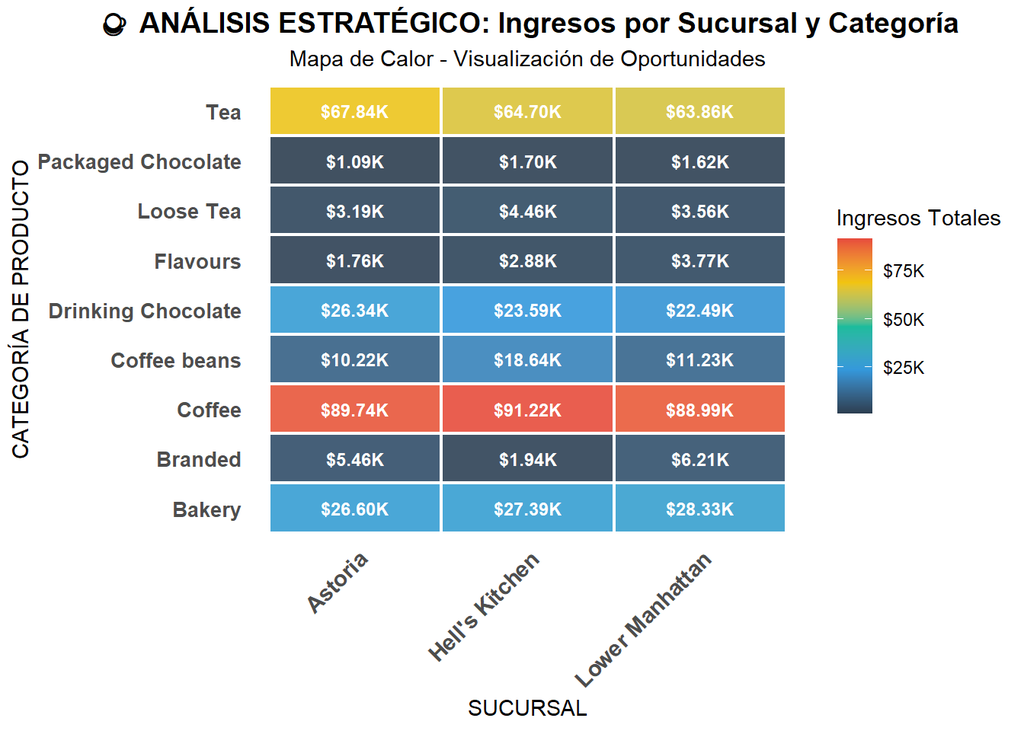

El análisis de las categorías de producto revela patrones muy claros en el comportamiento de los clientes según su ubicación geográfica. El café se mantiene como el producto indiscutiblemente principal en las tres sucursales, generando ingresos extraordinariamente consistentes que oscilan entre los 89 y 91 mil dólares en cada ubicación. Esta uniformidad demuestra que sin importar la zona, los clientes acuden a Vícsha principalmente por su café, confirmando que esta es la columna vertebral del negocio y el producto que define la experiencia del cliente.

La panadería emerge como el complemento perfecto al café, mostrando un desempeño sólido en todas las ubicaciones con ingresos entre 26 y 28 mil dólares. Lower Manhattan lidera ligeramente esta categoría, sugiriendo que los clientes de zonas más comerciales tienen mayor tendencia a complementar su bebida con un producto de panadería. Lo interesante es que esta categoría mantiene una performance estable, indicando que se ha consolidado como el acompañamiento natural del café en la mente del consumidor.

Las diferencias más significativas aparecen en categorías especializadas como los granos de café y los productos de marca. Hell’s Kitchen domina abrumadoramente la venta de granos de café con 18.6 mil dólares, casi el doble que las otras sucursales. Esto revela que esta ubicación atrae a un tipo de cliente más conocedor, interesado en preparar café en casa, mientras que las otras sucursales tienen clientes más orientados al consumo inmediato. Por otro lado, los productos de marca muestran una brecha dramática: Lower Manhattan genera 6.2 mil dólares mientras Hell’s Kitchen apenas alcanza 1.9 mil dólares, indicando que la disposición a pagar por productos premium está directamente vinculada al poder adquisitivo de la zona.

Estos hallazgos pintan un panorama claro: cada sucursal ha desarrollado un perfil de cliente distinto con preferencias específicas. Lower Manhattan atrae clientes orientados al premium y la experiencia gourmet, Hell’s Kitchen atrae conocedores del café que valoran la autenticidad, y Astoria mantiene una base de clientes leales con gustos más tradicionales. Esta comprensión permite diseñar estrategias de surtido y marketing altamente personalizadas que maximicen el potencial de cada ubicación.

### 5.6 🟫 Análisis por mes

| mes_abreviado | transacciones | ingreso_total | ingreso_minimo | ingreso_maximo | rango_ingresos | ingreso_promedio | ingreso_mediano | desviacion_ingresos | desviacion_mediana | cv_ingresos | q1_ingresos | q3_ingresos |
| --- | --- | --- | --- | --- | --- | --- | --- | --- | --- | --- | --- | --- |
| MES ENE | 17314 | 81677.74 | 0.8 | 360 | 359.2 | 4.72 | 3.75 | 4.95 | 5.05 | 104.99 | 3 | 6 |
| MES FEB | 16359 | 76145.19 | 0.8 | 45 | 44.2 | 4.65 | 3.75 | 3.02 | 3.15 | 64.9 | 3 | 6 |
| MES MAR | 21229 | 98834.68 | 0.8 | 72 | 71.2 | 4.66 | 3.75 | 3.08 | 3.21 | 66.14 | 3 | 6 |
| MES ABR | 25335 | 118941.08 | 0.8 | 360 | 359.2 | 4.69 | 3.75 | 4.39 | 4.49 | 93.41 | 3 | 6 |
| MES MAY | 33527 | 156727.76 | 0.8 | 360 | 359.2 | 4.67 | 3.75 | 4.08 | 4.18 | 87.26 | 3 | 6 |
| MES JUN | 35352 | 166485.88 | 0.8 | 360 | 359.2 | 4.71 | 3.75 | 4.89 | 4.98 | 103.75 | 3 | 6 |

Este análisis mensual se desarrolló como complemento esencial al análisis previo por sucursal y categorías de producto, con el objetivo de identificar patrones temporales y estacionalidad en el comportamiento de ventas a lo largo del primer semestre del año. Básicamente, este análisis por mes nos permite entender cuándo ocurren los picos de desempeño y cómo evolucionan las ventas en el tiempo.

Trabajamos con el gráfico de barras agrupadas como herramienta visual principal porque nos permitió identificar de manera inmediata:

- Tendencias de crecimiento o decrecimiento mensual
- Patrones estacionales consistentes entre sucursales
- Meses críticos de máximo y mínimo desempeño

[figure not shown]

### 5.7 🟫 Análisis por turno horario

| turno | transacciones | ingreso_total | ingreso_minimo | ingreso_maximo | rango_ingresos | ingreso_promedio | ingreso_mediano | desviacion_ingresos | desviacion_mediana | cv_ingresos | q1_ingresos | q3_ingresos |
| --- | --- | --- | --- | --- | --- | --- | --- | --- | --- | --- | --- | --- |
| HORARIO DE LA MAÑANA | 99173 | 468848.91 | 0.8 | 360 | 359.2 | 4.73 | 3.75 | 4.81 | 4.9 | 101.66 | 3 | 6 |
| HORARIO DE LA TARDE/NOCHE | 49943 | 229963.42 | 0.8 | 45 | 44.2 | 4.6 | 3.75 | 2.73 | 2.86 | 59.39 | 3 | 6 |

Este análisis por turno horario se desarrolló como complemento estratégico a los análisis previos por sucursal y mes, con el objetivo fundamental de identificar los patrones de consumo a lo largo del día y optimizar la operación según las franjas horarias de mayor demanda.

Mientras el análisis por sucursal nos mostró dónde se generan los ingresos y el análisis por mes reveló cuándo ocurren los picos de ventas, este análisis por turno nos permite entender cómo se distribuye el consumo durante el día y en qué horarios debemos focalizar nuestros esfuerzos operativos.

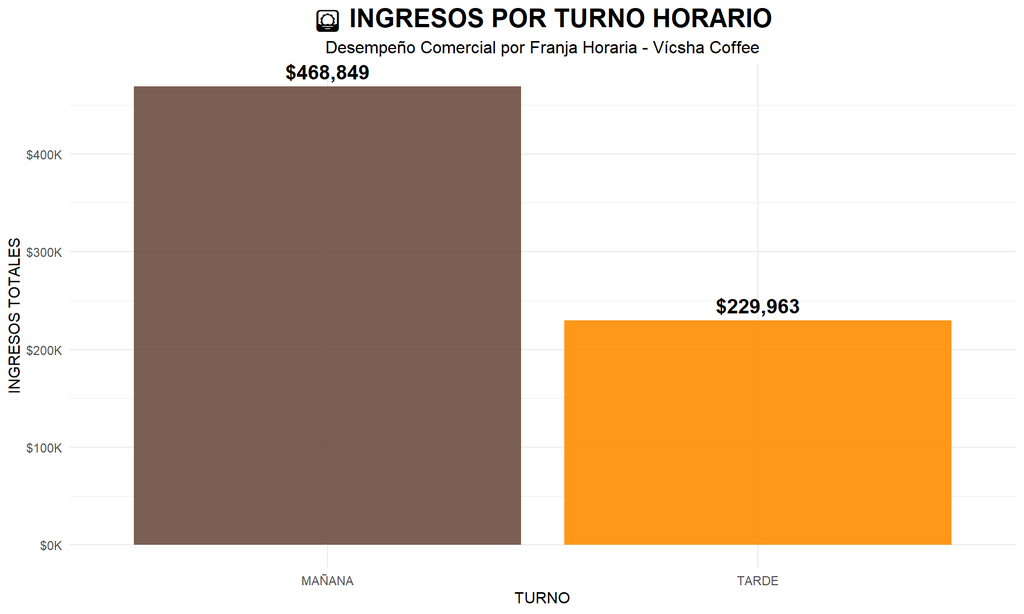

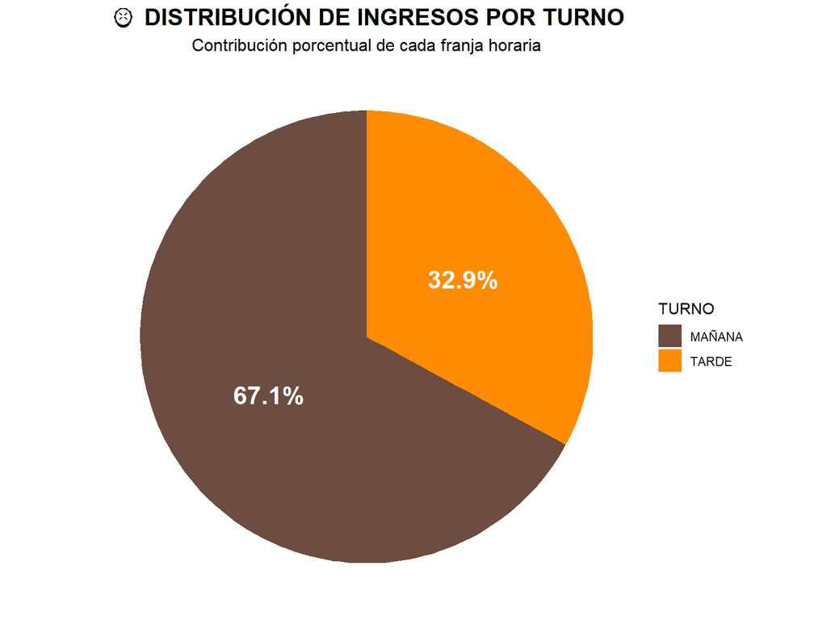

El turno de la mañana emerge como el período más crítico para el negocio, concentrando el 67.1% de los ingresos totales con $468,849 generados. Esta franja horaria no solo lidera en volumen monetario, sino que también registra la mayor cantidad de transacciones (99,173) y el ticket promedio más alto ($4.73), consolidándose como el corazón operativo de Vícsha Coffee.

La marcada diferencia entre el turno de la mañana (67.1%) y la tarde (32.9%) revela una oportunidad estratégica significativa. Mientras la mañana opera a máxima capacidad, la tarde presenta un potencial de crecimiento sustancial, con $229,963 en ingresos que podrían optimizarse mediante estrategias comerciales específicas.

El ticket promedio se mantiene notablemente consistente across todos los turnos ($4.73 en mañana vs $4.60 en tarde), indicando que la experiencia de compra y el perfil de gasto del cliente son similares independientemente del horario. Esta consistencia sugiere que las estrategias de upselling y cross-selling podrían aplicarse uniformemente.

## 6 🧠 Conclusión Final

El análisis estadístico de ventas de la franquicia Vícsha y cada una de sus sucursales ha facilitado la creación de una perspectiva precisa del comportamiento de consumo. Mediante una segmentación que abarca ubicación, categoría de producto, temporalidad y franja horaria, se han detectado patrones consistentes que señalan tanto fortalezas ya establecidas como oportunidades específicas de crecimiento.

La implementación de estrategias personalizadas por sucursal permitirá que nuestra cartera de clientes se sienta genuinamente escuchada y atendida:

Para Lower Manhattan, recomendamos programas de fidelización premium que reconozcan la lealtad de su base clientelar, complementados con capacitación especializada del personal en técnicas de ventas consultivas que enfaticen la experiencia sensorial del café.

En Hell’s Kitchen, la estrategia debe centrarse en gestión de relaciones con clientes de alto valor, mediante eventos exclusivos después del horario comercial y programas de membresía que ofrezcan acceso prioritario a lanzamientos limitados. El personal requiere formación avanzada en perfiles de café y maridajes.

Astoria se beneficiaría de campañas de captación y retención que capitalicen su estabilidad, con énfasis en experiencias comunitarias y programas de recomendación que fortalezcan el sentido de pertenencia.

Finalmente, el análisis por turno confirma que la mañana es el corazón operativo de Vícsha, concentrando más del 67% de los ingresos, el mayor volumen de transacciones y el ticket promedio más alto. Esta franja es el momento de máxima eficiencia. Aunque la tarde es menos rentable, su perfil de gasto similar abre la puerta a estrategias de activación como promociones específicas y campañas de fidelización .La marcada predominancia del turno matutino demanda una reevaluación estratégica de la asignación de recursos. Implementando rotación inteligente del personal más experimentado hacia los horarios de mayor volumen, y desarrollando incentivos específicos para el turno vespertino, podemos iniciar un ciclo virtuoso de mejora continua.

### 6.1 📌 Recomendaciones Estratégicas

• Segmentar la gestión por sucursal, adaptando surtido, promociones y experiencia según el perfil de cliente local.

• Fortalecer el turno de la mañana, manteniendo su eficiencia operativa y explorando estrategias para replicar su éxito en la tarde.

• Optimizar el surtido por categoría, potenciando productos premium en Lower Manhattan, granos en Hell’s Kitchen y especialidades locales en Astoria.

• Implementar visualizaciones operativas en tiempo real, que permitan monitorear el desempeño por franja horaria y categoría, facilitando decisiones ágiles.